# EDA_amy

Amy Pitts

2022-04-21

## Data import

I am going to take all the code she gave us and run it first.

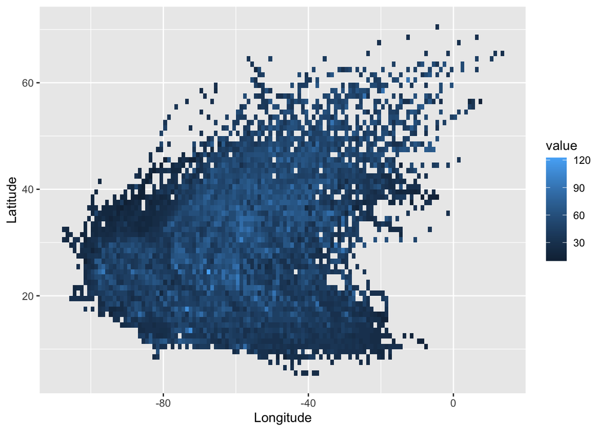

```r
dt = read.csv("hurrican703.csv")
dt %>%
  ggplot(aes(x = Longitude, y = Latitude)) +
    stat_summary_2d(
      data = dt,
      aes(x = Longitude, y = Latitude, z = dt$Wind.kt),
      fun = median,
      binwidth = c(1, 1),
      show.legend = TRUE
  )
```

```r
dt <- as.data.table(dt)
summary(dt)
```

```
##       ID                Season        Month              Nature
##  Length:22038       Min.   :1950   Length:22038       Length:22038
##  Class :character   1st Qu.:1969   Class :character   Class :character
##  Mode  :character   Median :1989   Mode  :character   Mode  :character
##                     Mean   :1986
##                     3rd Qu.:2003
##                     Max.   :2013
##      time              Latitude       Longitude          Wind.kt
##  Length:22038       Min.   : 5.00   Min.   :-107.70   Min.   : 10.00
##  Class :character   1st Qu.:18.70   1st Qu.: -78.70   1st Qu.: 30.00
##  Mode  :character   Median :26.50   Median : -64.05   Median : 45.00
##                     Mean   :26.99   Mean   : -62.91   Mean   : 52.28
##                     3rd Qu.:33.60   3rd Qu.: -48.60   3rd Qu.: 65.00
##                     Max.   :70.70   Max.   :  13.50   Max.   :165.00
```

The data avaiable to use is `ID`, `Season`, `Month`, `Nature`, `time`, `Latitude`, `Longitude` and `Wind.kt`.

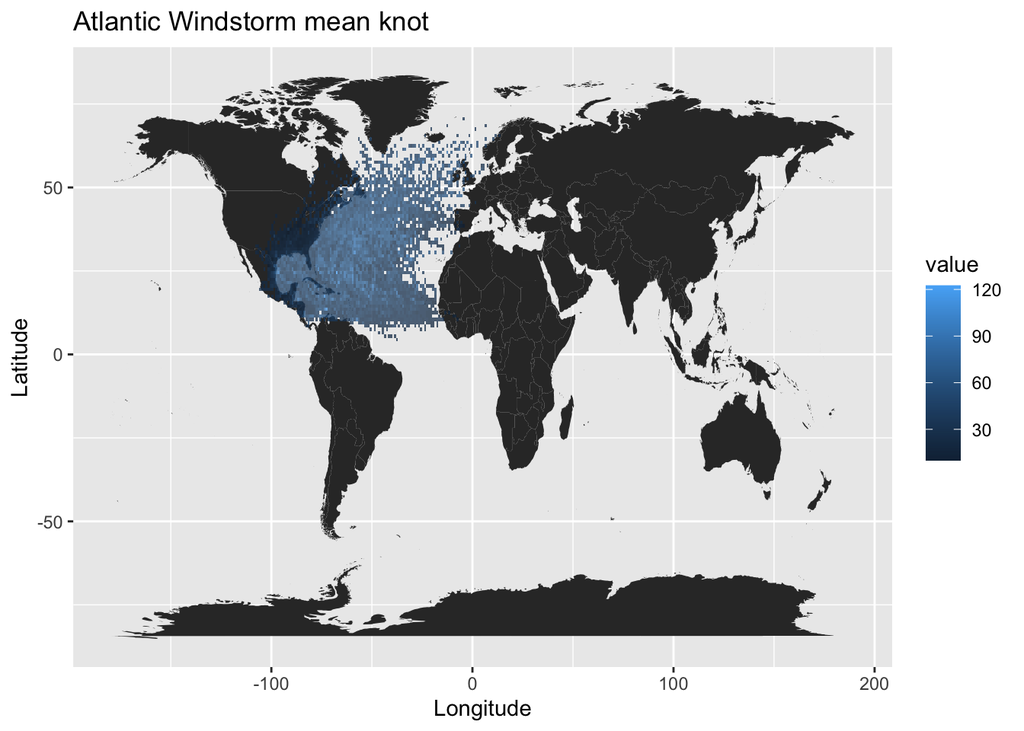

```r
map <- ggplot(data = dt, aes(x = Longitude, y = Latitude)) +
  geom_polygon(
    data = map_data(map = 'world'),
    aes(x = long, y = lat, group = group)
  )
map +
  stat_summary_2d(
    data = dt,
    aes(x = Longitude, y = Latitude, z = dt$Wind.kt),
    fun = median, binwidth = c(1, 1),
    show.legend = TRUE,
    alpha = 0.75
  ) +
  ggtitle(paste0("Atlantic Windstorm mean knot"))
```

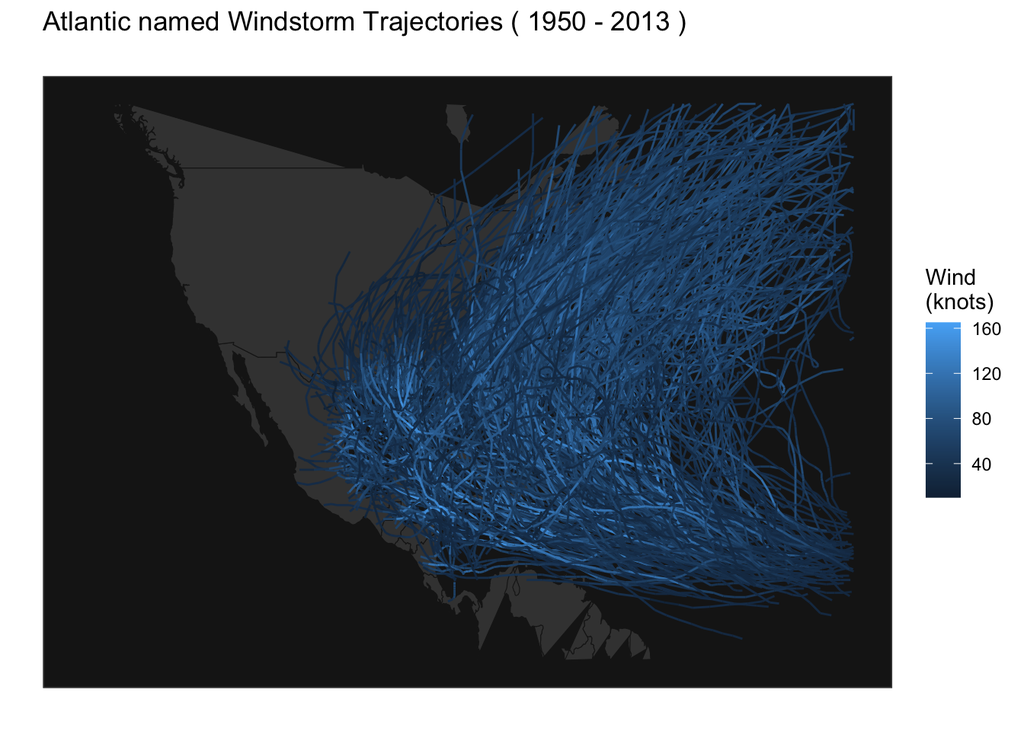

```r
map <- ggplot(dt, aes(x = Longitude, y = Latitude, group = ID)) +
  geom_polygon(
    data = map_data("world"),
    aes(x = long, y = lat, group = group),
    fill = "gray25", colour = "gray10", size = 0.2
  ) +
  geom_path(data = dt, aes(group = ID, colour = Wind.kt), size = 0.5) +
  xlim(-138, -20) + ylim(3, 55) +
  labs(x = "", y = "", colour = "Wind \n(knots)") +
  theme(panel.background = element_rect(fill = "gray10", colour = "gray30"),
        axis.text.x = element_blank(), axis.text.y = element_blank(),
        axis.ticks = element_blank(), panel.grid.major = element_blank(),
        panel.grid.minor = element_blank())

seasonrange <- paste(range(dt[, Season]), collapse=" - ")

map + ggtitle(paste("Atlantic named Windstorm Trajectories (",
                     seasonrange, ")\n"))
```

Show hurricance tracks by month

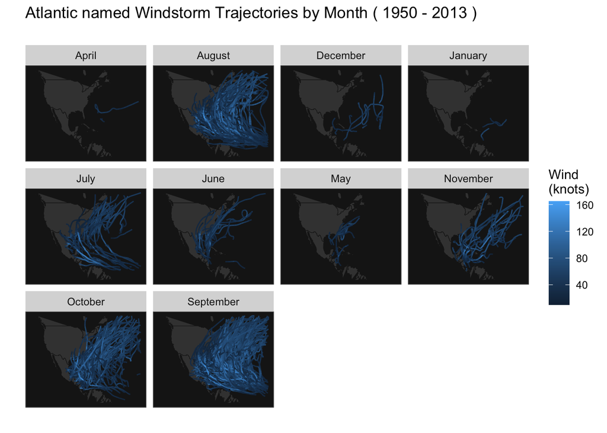

```r
mapMonth <- map + facet_wrap(~ Month) +
  ggtitle(paste("Atlantic named Windstorm Trajectories by Month (",
                 seasonrange, ")\n"))
mapMonth
```

It bothers me that months are not in order… I am going to try to force it to be in order.

Show hurricance tracks by month

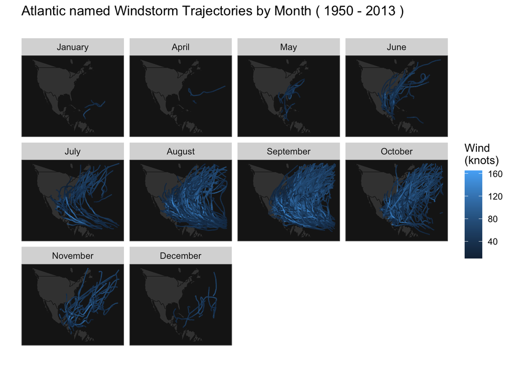

```r
df_temp = dt %>%
  mutate(
    Nature = factor(Nature),
    Season = factor(Season), # season is year not season....
    #Month = factor(Month),
    Month = factor(Month, levels = c(month.name)),
  )

map <- ggplot(df_temp, aes(x = Longitude, y = Latitude, group = ID)) +
  geom_polygon(
    data = map_data("world"),
    aes(x = long, y = lat, group = group),
    fill = "gray25", colour = "gray10", size = 0.2
  ) +
  geom_path(data = df_temp, aes(group = ID, colour = Wind.kt), size = 0.5) +
  xlim(-138, -20) + ylim(3, 55) +
  labs(x = "", y = "", colour = "Wind \n(knots)") +
  theme(panel.background = element_rect(fill = "gray10", colour = "gray30"),
        axis.text.x = element_blank(), axis.text.y = element_blank(),
        axis.ticks = element_blank(), panel.grid.major = element_blank(),
        panel.grid.minor = element_blank())

seasonrange <- paste(range(dt[, Season]), collapse=" - ")

mapMonth <- map + facet_wrap(~ Month) +
  ggtitle(paste("Atlantic named Windstorm Trajectories by Month (",
                 seasonrange, ")\n"))
mapMonth
```

### New Visualizations

Data Transformation (Pushing some variables to factor) Note that the Month is pushed to a factor that have a new level for each month. However, in our dataset we have no observations for February and march. When I introduce this level in the table it shows no data for those two months. There are no NAs in our data, the level function just shows that there is no data for that month.

```r
df_temp = dt %>%
  mutate(
    Nature = factor(Nature),
    Season = factor(Season), # season is year not season....
    #Month = factor(Month),
    Month = factor(Month, levels = c(month.name)),
  )

df_temp %>%
  #arrange(match(Month, month.name)) %>%
  select(Nature, Wind.kt, Latitude, Longitude,  Month ) %>%
  tbl_summary(by =Nature ) %>%
  add_overall() %>%
  modify_spanning_header(c("stat_1", "stat_2","stat_3","stat_4","stat_5") ~ "**Nature of the Hurricane**")
```

| **Characteristic** | **Overall**, N = 22,038<sup>1</sup> | **Nature of the Hurricane** **DS**, N = 971<sup>1</sup> | **Nature of the Hurricane** **ET**, N = 2,154<sup>1</sup> | **Nature of the Hurricane** **NR**, N = 96<sup>1</sup> | **Nature of the Hurricane** **SS**, N = 756<sup>1</sup> | **Nature of the Hurricane** **TS**, N = 18,061<sup>1</sup> |
| --- | --- | --- | --- | --- | --- | --- |
| Wind.kt | 45 (30, 65) | 25 (20, 30) | 40 (30, 50) | 25 (20, 25) | 40 (30, 50) | 50 (35, 70) |
| Latitude | 26 (19, 34) | 23 (17, 31) | 43 (38, 50) | 18 (14, 22) | 32 (29, 36) | 25 (18, 31) |
| Longitude | -64 (-79, -49) | -66 (-81, -45) | -47 (-62, -28) | -64 (-69, -55) | -65 (-74, -51) | -66 (-80, -51) |
| Month |  |  |  |  |  |  |
| January | 69 (0.3%) | 5 (0.5%) | 0 (0%) | 0 (0%) | 19 (2.5%) | 45 (0.2%) |
| February | 0 (0%) | 0 (0%) | 0 (0%) | 0 (0%) | 0 (0%) | 0 (0%) |
| March | 0 (0%) | 0 (0%) | 0 (0%) | 0 (0%) | 0 (0%) | 0 (0%) |
| April | 53 (0.2%) | 0 (0%) | 23 (1.1%) | 0 (0%) | 17 (2.2%) | 13 (<0.1%) |
| May | 278 (1.3%) | 39 (4.0%) | 18 (0.8%) | 0 (0%) | 57 (7.5%) | 164 (0.9%) |
| June | 821 (3.7%) | 34 (3.5%) | 113 (5.2%) | 0 (0%) | 59 (7.8%) | 615 (3.4%) |
| July | 1,524 (6.9%) | 95 (9.8%) | 103 (4.8%) | 19 (20%) | 41 (5.4%) | 1,266 (7.0%) |
| August | 5,223 (24%) | 291 (30%) | 319 (15%) | 14 (15%) | 108 (14%) | 4,491 (25%) |
| September | 8,977 (41%) | 254 (26%) | 855 (40%) | 39 (41%) | 163 (22%) | 7,666 (42%) |
| October | 3,791 (17%) | 164 (17%) | 550 (26%) | 11 (11%) | 147 (19%) | 2,919 (16%) |
| November | 1,066 (4.8%) | 58 (6.0%) | 159 (7.4%) | 13 (14%) | 86 (11%) | 750 (4.2%) |
| December | 236 (1.1%) | 31 (3.2%) | 14 (0.6%) | 0 (0%) | 59 (7.8%) | 132 (0.7%) |

<sup>1</sup> Median (IQR); n (%)

Prob can’t use hurricanes with 1 or 2 observations. Going to need more.

## Data Description

There are 702 unique hurricanes in this dataset all the occurred in the north american region between the years 1950 to 2013. Data on the storm’s location (longitude & latitude) and maximum wind speed were recorded every 6 hours stored in the time variable. Data is also collected on the season (aka the year), the storm’s month, and the nature of the hurricane; (Extra Tropical (ET), Disturbance (DS), Not Rated (NR), Sub Tropical (SS), and Tropical Storm (TS)). The number of observations we have for each storm range from 1 to 118 with a mean value of 31 observations.

```r
library(lubridate)
dt_temp = dt %>%
  mutate(
    Nature = factor(Nature),
    Season = factor(Season), # season is year not season....
    Month = factor(Month, levels = c(month.name)),
  ) %>%
  tidyr::separate(
    time, c('Date', 'Time'),
                       sep = ' ', extra = 'merge') %>%
  tidyr::separate(
    Date, c('year_num', 'month_num', 'day'),
                       sep = '-', extra = 'merge') %>%
  tidyr::separate(
    Time, c('hour', 'min', 'sec'),
                       sep =':', extra = 'merge')  %>%
  select(-c(year_num, month_num, sec)) %>%
  select(ID, Nature, Latitude, Longitude, Wind.kt, Season, Month, day, hour, min)

dt_temp %>% head()
```

```
##           ID Nature Latitude Longitude Wind.kt Season  Month day hour min
## 1: ABLE.1950     TS     17.1     -55.5      35   1950 August  12   00  00
## 2: ABLE.1950     TS     17.7     -56.3      40   1950 August  12   06  00
## 3: ABLE.1950     TS     18.2     -57.4      45   1950 August  12   12  00
## 4: ABLE.1950     TS     19.0     -58.6      50   1950 August  12   18  00
## 5: ABLE.1950     TS     20.0     -60.0      50   1950 August  13   00  00
## 6: ABLE.1950     TS     20.7     -61.1      50   1950 August  13   06  00
```

```r
#dt_temp %>% filter(ID == "GINGER.1971")

dt_temp %>% filter(min != "00") %>% dim() # %>% filter(ID =="SANDY.2012")
```

```
## [1] 103  10
```

```r
dt_temp %>% filter(ID =="SANDY.2012") %>% head()
```

```
##            ID Nature Latitude Longitude Wind.kt Season   Month day hour min
## 1: SANDY.2012     DS     14.3     -77.4      25   2012 October  21   18  00
## 2: SANDY.2012     DS     13.9     -77.8      25   2012 October  22   00  00
## 3: SANDY.2012     DS     13.5     -78.2      25   2012 October  22   06  00
## 4: SANDY.2012     TS     13.1     -78.6      30   2012 October  22   12  00
## 5: SANDY.2012     TS     12.7     -78.7      35   2012 October  22   18  00
## 6: SANDY.2012     TS     12.6     -78.4      40   2012 October  23   00  00
```

We have data collected between the 6 hours. We need to think about how to handle this. I think we should only use the 00, 06, 12, 18 data.

## Filtering

```r
dt_6hours <- dt_temp %>% filter(min == "00")


temp = table(dt_6hours$ID) %>% as.data.frame()

id_get_rid <- temp %>% arrange(Freq) %>% filter(Freq <= 7) %>% pull(Var1)

dt_6hour_rm <- dt_6hours %>% filter(!(ID %in% c(id_get_rid))) # onlt getting rid of 214
```